# Coronavirus EDA Executive Summary

Data Science I (STAT 301-1)

Derex Wangmang

## Executive Summary

My Exploratory Data Analysis focused on visualizing how the coronavirus exacerbated existing inequalities. As part of my project, I retrieved datasets that included cases and deaths in the Chicagoland area, diabetes rates, asthma rates, and income levels. Because my original dataset about COVID-19 cases was separated by ZIP code, I used ZIP code as the unique key across datasets. I explored the following questions:

- What is the overall trend of coronavirus cases and deaths in the Chicagoland area?
- How does median income relate to coronavirus case and death rates?
- How do medical conditions, specifically diabetes and asthma rates, relate to the rates of coronavirus cases and deaths?

I processed my data by filtering out all observations with ZIP codes outside the ZIP codes from the case data. I then removed rows with missing or incomplete data. Additionally, I disaggregated data that initially represented multiple ZIP codes. I also leveraged `tidycensus` to retrieve data about the median income from the US Census Bureau.

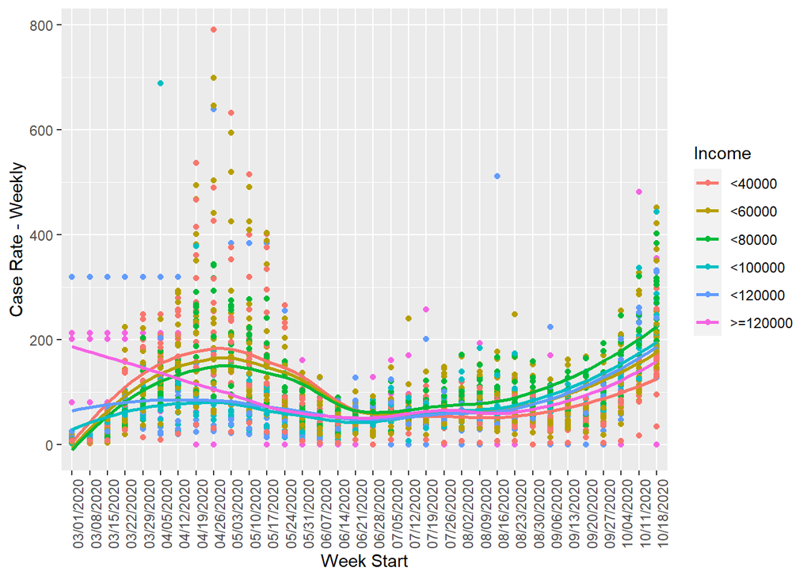

2. ZIP codes with higher asthma rates had higher death rates than the death rates for ZIP codes with lower asthma rates. While the trends are the same, with a peak around 04/26 and a constant rate of near 0 afterwards, the death rates were significantly higher than that of the ZIP codes with the lowest asthma rates. Since the coronavirus affects the respiratory system, and asthma is a medical condition that affects the lungs, I expected the death rate to be higher for the ZIP code with higher rates of asthma. This visualization below quantifies my assumption, illustrating how the populations with higher asthma rates have larger peaks that extend over longer periods of time.

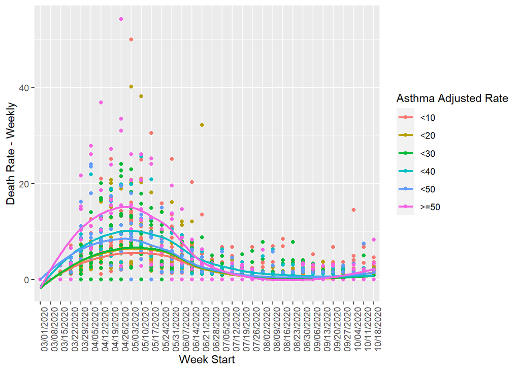